# What influences the destination of disaster migrants? Evidence from Hurricane Katrina

June 2, 2017

## Overview

Talk will cover:

- Motivation and Research Question
- Data
- Empirical Strategy
- Results
- Economic Relevance

## Motivation and Research Question

## Growing Risks of Natural Disasters

- Climate change implies more frequent and more damaging disasters (Van Aalst 2006)
- Disasters do not discriminate with respect to wealth, but institutions and wealth helps mitigate deaths (Kahn 2005)
- Growing fiscal and social costs within the United States
  - More frequent FEMA disaster declarations
  - Higher federal costs for declared disasters
  - Non-disaster government transfers increases may understate true cost (Deryugina 2016)

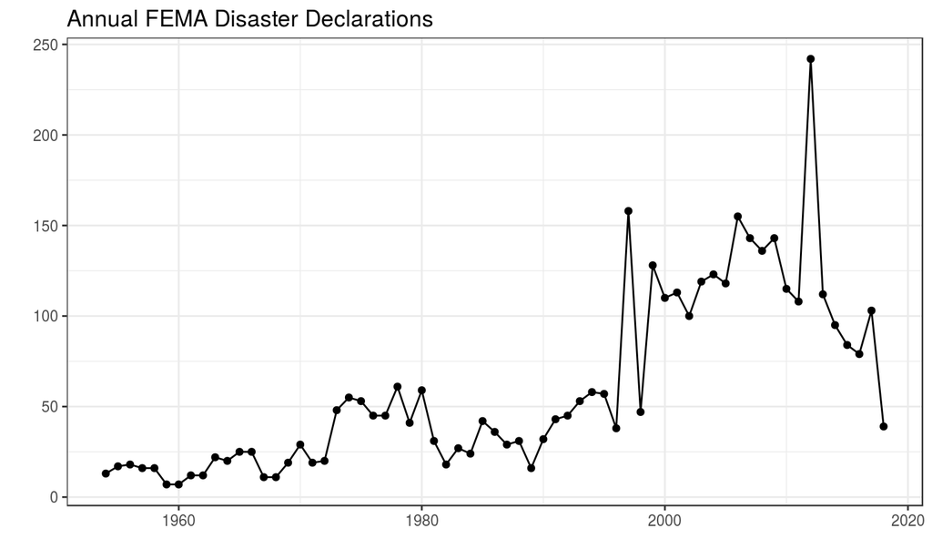

## Out of the Frying Pan?

- Some evidence that people move after big disasters
  - Boustan et al. (2017)
  - Carleton and Hsiang (2016)
- Rational actors respond to disasters by moving to new locations
  - Because their homes are destroyed?
  - Because the local economy is harmed?
  - Because they have updated their priors about risks?
- Move people out of dangerous areas, but does this lower future disaster costs?
- All else equal, higher exposure areas should see lower migration rates

## And Into the Fire?

- Disaster exposure is spatially correlated
- Disasters are negative income shocks and long moves are costly
- People tend to move relatively short distances
- If disasters induce shorter moves, migration may not lower future disaster costs
- **Shorter moves may not lower costs**
  - **Key question**: where do disaster migrants locate to?
  - And does migration mitigate impacts of disasters or simply rearrange the deck chairs?

## Hurricane Katrina

## Impacts

- Category 3 Hurricane at landing (sustained winds of 100–140 miles per hour)
- Landed 25 August 2005 in Louisiana
- Total damage estimated at $108 billion (Knobb, Rhome, and Brown 2005)
- Deaths appear to be at least 1,500 (Beven et al. 2008)
- Triggered response of over $5.7 billion in FEMA disaster relief

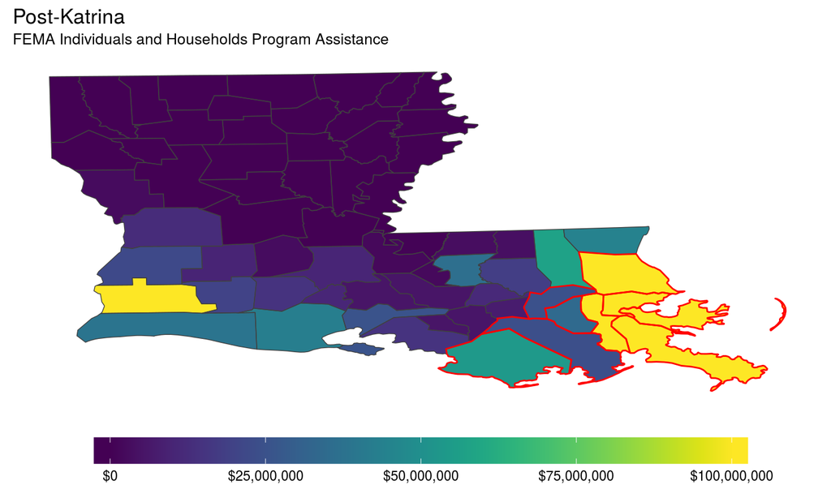

## How Did Katrina Affect New Orleans Migrants?

- Data from IRS county-to-county migration used, tracks filed tax returns at FIPS code from year to year
- Typical outmigration from New Orleans area from 2000 to 2010 excluding 2005 averaged 21,482 outmigrants per year (average population of 1,421,693)
  - Parishes - Jefferson, Lafourche, Orleans, Plaquemines, St. Bernard, St. Charles, St. John the Baptist, and St. Tammany, and Terrebonne
  - Fairly stable spatial distribution - nearby and large metro regions
- In 2005, total of 181,854 outmigrants
  - Similar spatial pattern exists plus evident overflow

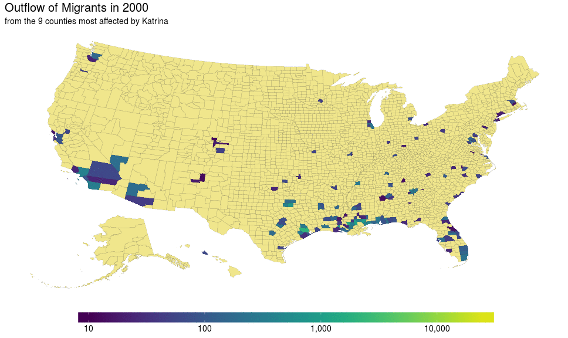

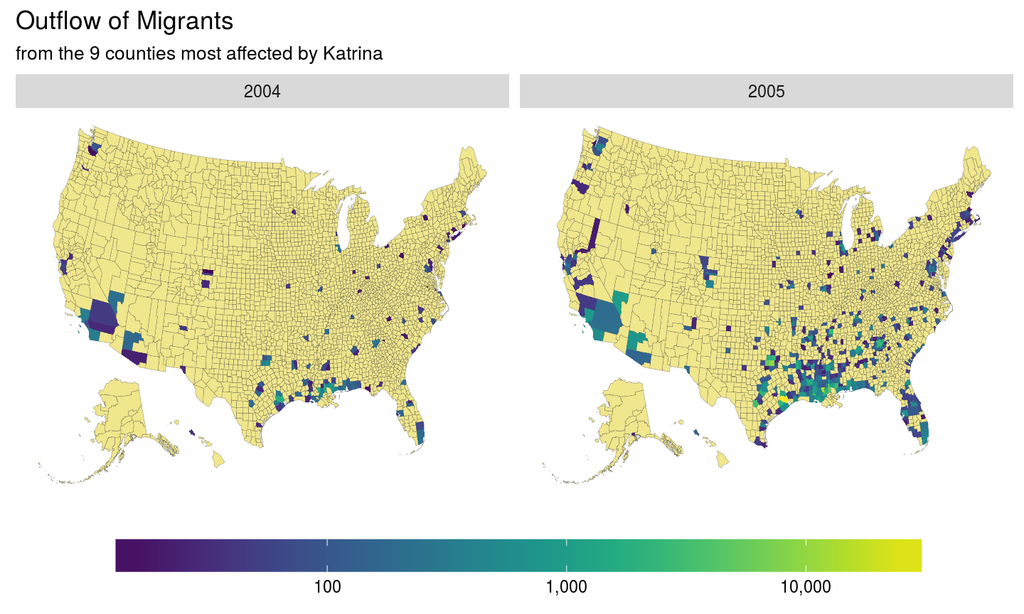

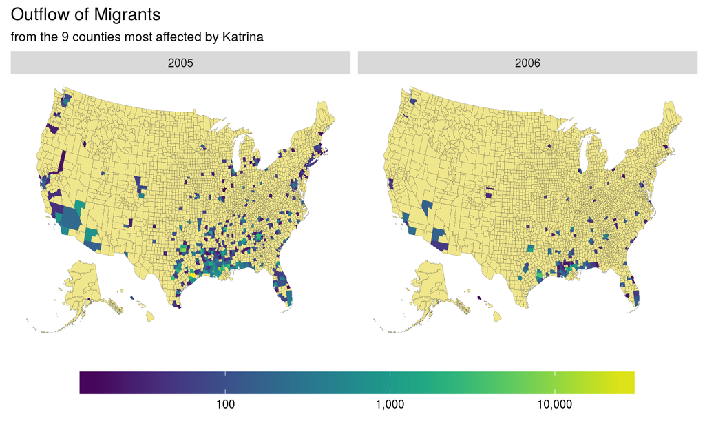

## Empirical Strategy

## Gravity Model

Beginings from Newtonian physics, which imply

\[ F = G \frac{m_1 m_2}{r^2} \]

\[ M_{ij} = k \frac{P_{i}^{\beta_1} P_{j}^{\beta_2}}{D_{ij}^{\gamma}} \]

## Modified

For outmigration from Katrina affected areas:

\[ m_{i,t} = \alpha + \gamma D_{i} + \beta_1 P_{i,t} + \beta_2 {Katrina} + \beta_3 \mathbf{X_{i,t}} + \varepsilon_{i,t}\]

- \(i\) indicates county destination and \(t\) indicates year
- \(m\) is migration measure
  - Raw flow, inverse hyperbolic sine, share of outflow, and indicator of positive migration
- \(D\) indicates distance from centroid of affected area
- \(P\) is the population for destination county
- \({Katrina}\) is dummy variable for 2005
- \(\mathbf{X_{i,t}}\) are economic characteristics: unemployment rate, median rent, average pay

## Modified

Model entails destination's distance from New Orleans, its population, a Katrina indicator for 2005, and economic indicators.

- Panel of migration outflow from affected counties from 2000 to 2010
- Start with baseline model of New Orleans area destinations
- Interact explanatory variables with Katrina variable
- Attribute change in effects to the disaster response

## Results

Baseline

|  | Flow | IHS | LP | Share |
| --- | --- | --- | --- | --- |
| Distance | -1.8062*** | -0.0239*** | -0.0048*** | -0.005*** |
| (hundreds of km) | (0.4165) | (0.0027) | (5e-04) | (0.0012) |
| Population | 193.1327* | 1.9915*** | 0.3992*** | 0.474** |
| (millions) | (110.3825) | (0.463) | (0.1027) | (0.2188) |
| Katrina | 51.6205*** | 0.4618*** | 0.092*** | -1e-04 |
|  | (12.9152) | (0.0222) | (0.005) | (0.0038) |
| Adjusted R-Squared | 0.037 | 0.305 | 0.288 | 0.114 |

Baseline Economic Characteristics

|  | Flow | IHS | LP | Share |
| --- | --- | --- | --- | --- |
| Unemployment Rate | -12.6374 | -1.4173*** | -0.3361*** | -0.1494** |
|  | (29.0974) | (0.3073) | (0.0689) | (0.0688) |
| Average Annual Pay | 0.7527* | 0.0155*** | 0.0036*** | 0.002* |
| (in thousands) | (0.4318) | (0.0042) | (9e-04) | (0.001) |
| Median Monthly Rent | -3.9009 | 0.0166 | 0.0057* | -0.0071 |
| (in hundreds) | (3.7921) | (0.0138) | (0.0031) | (0.0076) |
| Adjusted R-Squared | 0.037 | 0.305 | 0.288 | 0.114 |

Katrina Interactions

|  | Flow | IHS | LP | Share |
| --- | --- | --- | --- | --- |
| Distance | -1.1153*** | -0.0197*** | -0.004*** | -0.005*** |
| (hundreds of km) | (0.2699) | (0.0026) | (5e-04) | (0.0012) |
| Interaction | -7.2918*** | -0.0528*** | -0.0099*** | 2e-04 |
|  | (1.6765) | (0.0035) | (8e-04) | (6e-04) |
| Population | 101.5004** | 1.9065*** | 0.3929*** | 0.4588** |
| (millions) | (45.2713) | (0.4314) | (0.0989) | (0.1978) |
| Interaction | 1054.9499 | 0.7248** | 0.0198 | 0.1771 |
|  | (772.432) | (0.3459) | (0.0428) | (0.2535) |
| Katrina | 95.5467 | -1.5462*** | -0.3372*** | -0.0042 |
|  | (216.3368) | (0.2037) | (0.0366) | (0.0861) |
| Adjusted R-Squared | 0.112 | 0.336 | 0.309 | 0.115 |

Katrina Economic Interactions

|  | Flow | IHS | LP | Share |
| --- | --- | --- | --- | --- |
| Unemployment Rate | -55.4713*** | -1.4865*** | -0.3467*** | -0.1844*** |
|  | (15.697) | (0.2911) | (0.0678) | (0.0704) |
| Interaction | 1030.2041*** | 9.2898*** | 1.8593*** | 0.7037*** |
|  | (385.1283) | (1.4963) | (0.3017) | (0.2396) |
| Average Annual Pay | 0.4678** | 0.0138*** | 0.0033*** | 0.002** |
| (in thousands) | (0.2186) | (0.004) | (9e-04) | (0.001) |
| Interaction | 2.8474 | 0.028*** | 0.0053*** | 0 |
|  | (3.5034) | (0.0058) | (0.0012) | (0.0013) |
| Median Monthly Rent | -1.4195 | 0.0023 | 0.0024 | -0.0063 |
| (in hundreds) | (1.3117) | (0.0132) | (0.0031) | (0.0068) |
| Interaction | -29.4207 | 0.246*** | 0.056*** | -0.0091 |
|  | (36.7561) | (0.0275) | (0.0059) | (0.0132) |
| Adjusted R-Squared | 0.112 | 0.336 | 0.309 | 0.115 |

## Thank You

Questions or comments?

- email: dinterman.1@osu.edu

## References

Beven, John L, Lixion A Avila, Eric S Blake, Daniel P Brown, James L Franklin, Richard D Knabb, Richard J Pasch, Jamie R Rhome, and Stacy R Stewart. 2008. “Atlantic Hurricane Season of 2005.” *Monthly Weather Review* 136 (3): 1109–73.

Boustan, Leah Platt, Matthew E Kahn, Paul W Rhode, and Maria Lucia Yanguas. 2017. “The Effect of Natural Disasters on Economic Activity in Us Counties: A Century of Data.” National Bureau of Economic Research.

Carleton, Tamma A, and Solomon M Hsiang. 2016. “Social and Economic Impacts of Climate.” *Science* 353 (6304). American Association for the Advancement of Science: aad9837.

Deryugina, Tatyana. 2016. “The Fiscal Cost of Hurricanes: Disaster Aid Versus Social Insurance.” National Bureau of Economic Research.

Kahn, Matthew E. 2005. “The Death Toll from Natural Disasters: The Role of Income, Geography, and Institutions.” *Review of Economics and Statistics* 87 (2). MIT Press: 271–84.

Knobb, RD, JR Rhome, and RD Brown. 2005. “Tropical Cyclone Report: Hurricane Katrina.” Technical Report, NOAA National Hurricane Center, 23–30 August.

Stewart, John Q. 1941. “An Inverse Distance Variation for Certain Social Influences.” *Science* 93 (2404). American Association for the Advancement of Science: 89–90.

Van Aalst, Maarten K. 2006. “The Impacts of Climate Change on the Risk of Natural Disasters.” *Disasters* 30 (1). Wiley Online Library: 5–18.